# BGSA440AC - 1YUS77NT - Sort_178 - 4_5

Author: PSS RFS DR RF PTE PRE

april 25, 2025

##### BGSA440AC - 1YUS77NT - Sort_178 - 4_5

# Metadata

### Product Information

| Test Sort | Product | Basic Type | Lot | Wafer | Reticle | Probe Card |
| --- | --- | --- | --- | --- | --- | --- |
| Sort_178 | BGSA440AC | M6226A | 1YUS77NT | 4 | R9655A13 | M6226A |
| Sort_178 | BGSA440AC | M6226A | 1YUS77NT | 5 | R9655A13 | M6226A |

### Scope

| Test Sort | Requestor | Purpose | Description | Mile Stone |
| --- | --- | --- | --- | --- |
| Sort_178 | Michael | NA | Metal Fix, Proto 2b | P2 |

### Test Information

| Test Sort | Date In | Test Program | Test Revision | ATT6 Data Available IFX |
| --- | --- | --- | --- | --- |
| Sort_178 | 45622 | M6226A0012AKX4NIA | 0 | 45623 |

# Yield overview

## Stasticial Bin Analysis (SBA)

### SBA by count

| Test_sort | Date | LOT | Yield [%] | WAFER | Die_count | Wafer_count | HBIN (P) PASS_1 | HBIN (F) Continuity_6 | HBIN (F) Harmonics_12 | HBIN (F) Digital_7 |
| --- | --- | --- | --- | --- | --- | --- | --- | --- | --- | --- |
| Sort_178 | NA | All | 99.69 | All | 10560 | 2 | 10527 | 7 | 25 | 1 |
| Sort_178 | 2024-11-26 | 1YUS77NT | 99.53 | 4 | 5280 | 1 | 5255 | 4 | 20 | 1 |
| Sort_178 | 2024-11-26 | 1YUS77NT | 99.85 | 5 | 5280 | 1 | 5272 | 3 | 5 | NA |

### SBA by percent

| Test_sort | Date | LOT | Yield [%] | WAFER | Die_count | Wafer_count | HBIN (P) [%] PASS_1 | HBIN (F) [%] Continuity_6 | HBIN (F) [%] Harmonics_12 | HBIN (F) [%] Digital_7 |
| --- | --- | --- | --- | --- | --- | --- | --- | --- | --- | --- |
| Sort_178 | NA | All | 99.69 | All | 10560 | 2 | 99.688 | 0.066 | 0.237 | 0.009 |
| Sort_178 | 2024-11-26 | 1YUS77NT | 99.53 | 4 | 5280 | 1 | 99.527 | 0.076 | 0.379 | 0.019 |
| Sort_178 | 2024-11-26 | 1YUS77NT | 99.85 | 5 | 5280 | 1 | 99.848 | 0.057 | 0.095 | NA |

## Yield Pareto [Lot]

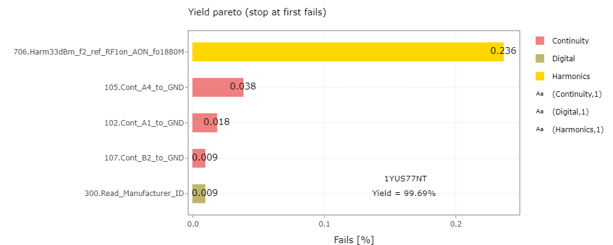

Yield Pareto by Test

### Fail count [Lot]

#### Fail count by B-Type

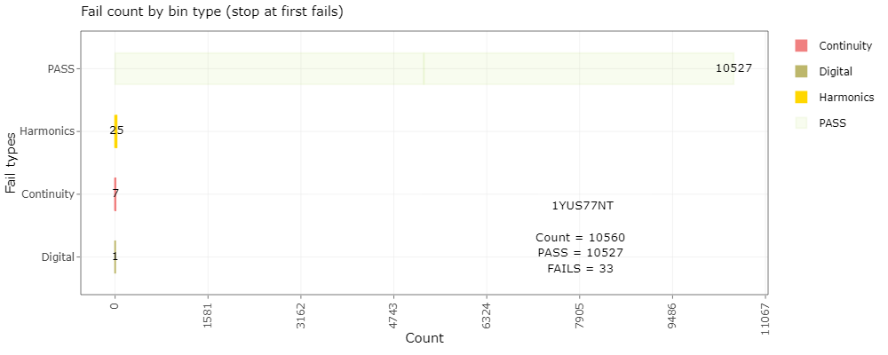

Fail count by B-Type

#### Fail count by TBIN

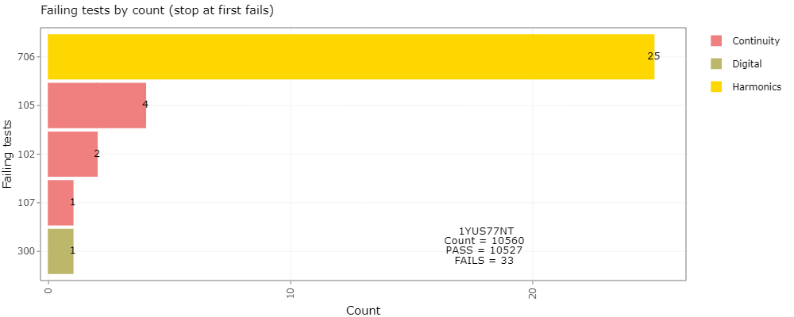

Fail count by TBIN

## Fails per Wafer [Lot]

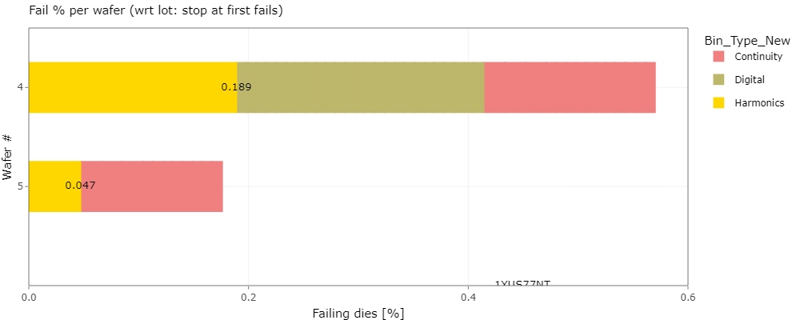

Fails per Wafer

## Cumulative yield [Lot]

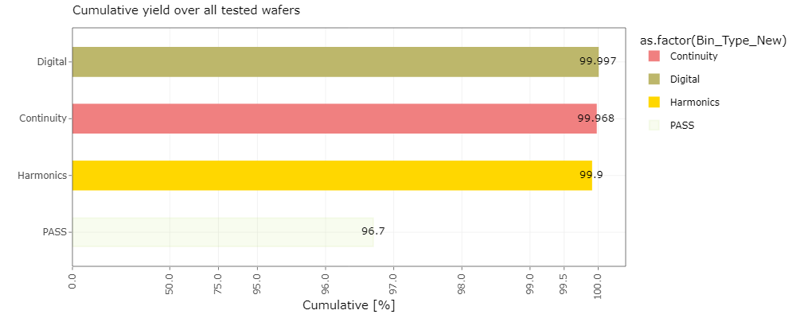

Cumulative yield

## Yield Pareto [Wafer]

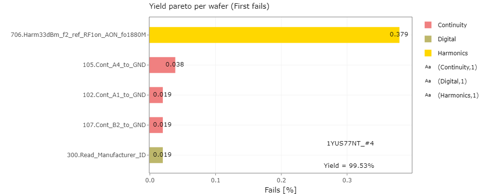

Yield Pareto [Wafer]

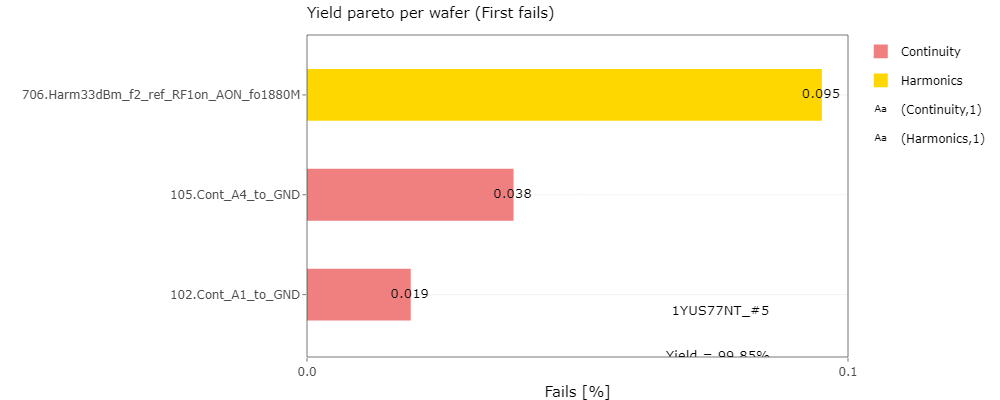

Yield Pareto [Wafer]

### Fail count [Wafer]

#### Fail count by B-Type [Wafer]

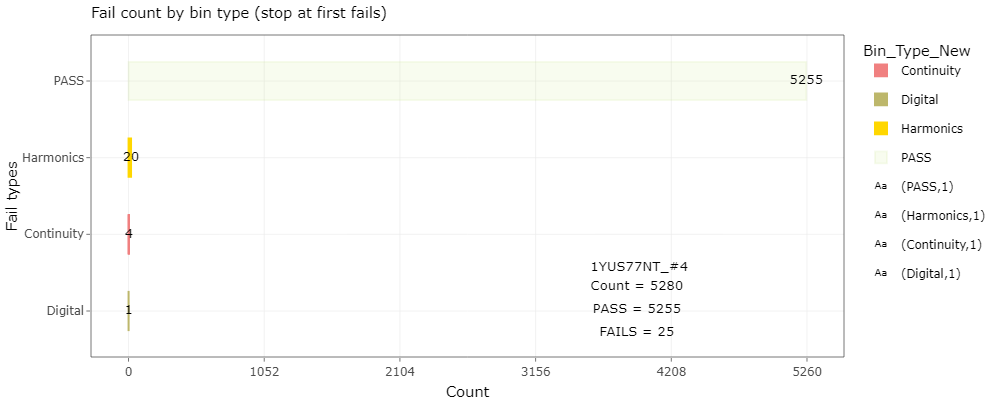

Fail count by B-Type [Wafer]

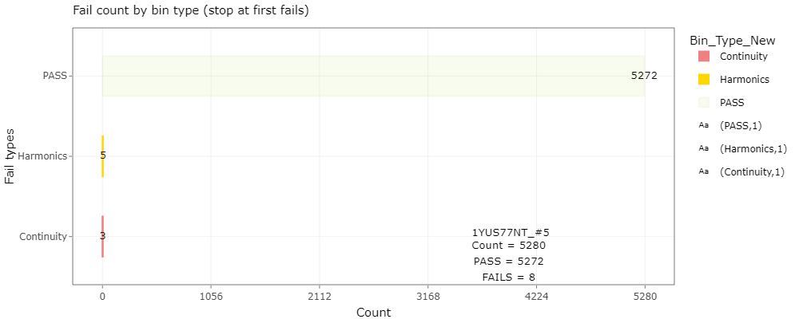

Fail count by B-Type [Wafer]

#### Fail count TBIN [Wafer]

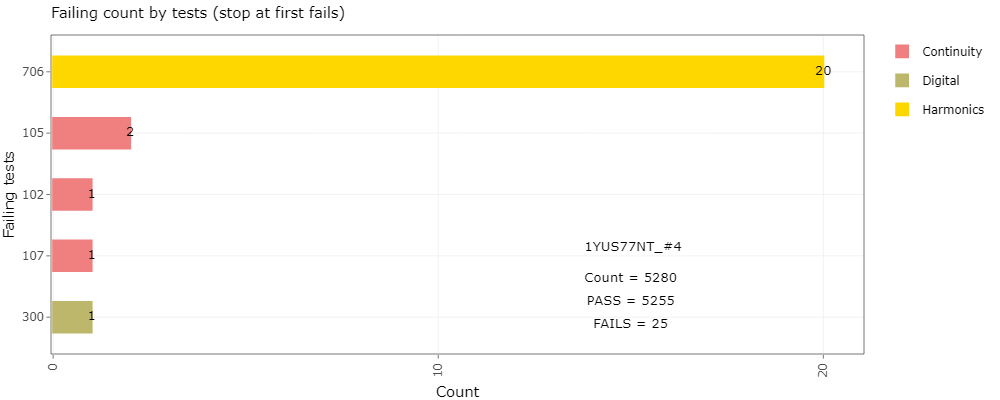

Yield Pareto by TBIN per Wafer

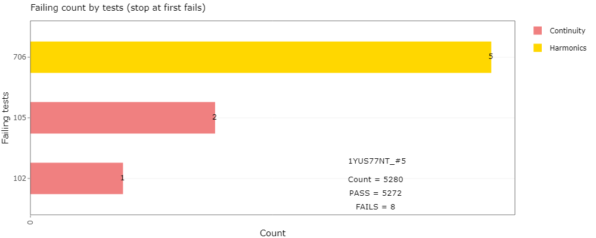

Yield Pareto by TBIN per Wafer

## Yield Cpk per Tests [Lot & Wafer]

### Yield_per_test_overall_LOT

| TNUM | TNAME | BIN_Nr | LSL | X.CPK2.0 | X.CPK1.67 | MIN | MEAN | MEDIAN | MAX | StD | X.CPK1.67.1 | X.CPK2.0.1 | USL | UNIT | Count | Fails | Yield | Cpk |
| --- | --- | --- | --- | --- | --- | --- | --- | --- | --- | --- | --- | --- | --- | --- | --- | --- | --- | --- |
| 1000001 | C2_Discharge | 16 | -0.1 | 155.0 | 186.0 | 0.0 | 0.0 | 0.0 | 0.0 | 0.0 | 187.1 | 155.9 | 0.1 | V | 10,560.0 | 0.0 | 100.0 | 310.0 |
| 104 | Cont_A3_to_GND | 6 | -1000 | 4.0 | 4.8 | −661.3 | −608.2 | −610.2 | −537.9 | 16.4 | 6.2 | 5.2 | -100 | mV | 10,560.0 | 0.0 | 100.0 | 7.9 |
| 102 | Cont_A1_to_GND | 6 | -1000 | 3.4 | 4.1 | −1,339.7 | −608.9 | −610.8 | −530.3 | 19.0 | 5.3 | 4.5 | -100 | mV | 10,560.0 | 2.0 | 100.0 | 6.8 |
| 103 | Cont_A2_to_GND | 6 | -1000 | 3.9 | 4.6 | −658.9 | −609.7 | −611.9 | −531.4 | 16.9 | 6.0 | 5.0 | -100 | mV | 10,558.0 | 0.0 | 100.0 | 7.7 |
| 108 | Cont_B3_to_GND | 6 | -1000 | 4.4 | 5.3 | −669.5 | −629.5 | −631.5 | −569.9 | 14.0 | 7.6 | 6.3 | -100 | mV | 10,560.0 | 0.0 | 100.0 | 8.8 |
| 106 | Cont_B1_to_GND | 6 | -1000 | 4.3 | 5.2 | −1,012.8 | −630.7 | −632.5 | −562.8 | 14.3 | 7.4 | 6.2 | -100 | mV | 10,560.0 | 1.0 | 100.0 | 8.6 |
| 107 | Cont_B2_to_GND | 6 | -1000 | 4.6 | 5.5 | −1,017.0 | −621.3 | −623.0 | −566.4 | 13.7 | 7.6 | 6.3 | -100 | mV | 10,559.0 | 1.0 | 100.0 | 9.2 |
| 105 | Cont_A4_to_GND | 6 | -1000 | 2.5 | 3.0 | −1,600.0 | −609.9 | −611.5 | −524.6 | 25.6 | 4.0 | 3.3 | -100 | mV | 10,559.0 | 4.0 | 100.0 | 5.1 |
| 109 | Cont_B4_to_GND | 6 | -1000 | 0.8 | 1.0 | −652.4 | −514.5 | −458.5 | −374.0 | 101.6 | 0.8 | 0.7 | -100 | mV | 10,556.0 | 0.0 | 100.0 | 1.4 |
| 100 | Cont_C1_to_GND | 6 | -750 | 13.4 | 16.1 | −331.7 | −321.7 | −322.2 | −112.5 | 5.3 | 8.3 | 7.0 | -100 | mV | 10,560.0 | 0.0 | 100.0 | 13.9 |
| 101 | Cont_C2_to_GND | 6 | -750 | 17.9 | 21.5 | −331.7 | −321.5 | −322.0 | −306.2 | 4.0 | 11.1 | 9.3 | -100 | mV | 10,560.0 | 0.0 | 100.0 | 18.5 |
| 200 | I_LowP_C1_1V8_PreVH_PreRFStress | 8 | 1 | 1.0 | 1.2 | 2.8 | 3.8 | 3.7 | 7.0 | 0.4 | 2.8 | 2.3 | 10 | uA | 10,560.0 | 0.0 | 100.0 | 2.1 |
| 201 | I_LowP_C1_1V95_VH_PreRFStress | 8 | 1 | 1.1 | 1.3 | 3.6 | 4.8 | 4.7 | 9.0 | 0.6 | 3.6 | 3.0 | 15 | uA | 10,560.0 | 0.0 | 100.0 | 2.2 |
| 202 | I_LowP_C1_1V8_PostVH_PreRFStress | 8 | 1 | 0.9 | 1.1 | 2.6 | 3.5 | 3.5 | 6.7 | 0.4 | 2.9 | 2.4 | 10 | uA | 10,560.0 | 0.0 | 100.0 | 1.9 |
| 203 | DELTA_I_LowP_C1_1V8_PostVH_PreRFStress | 8 | -5 | 11.8 | 14.1 | 0.0 | 0.3 | 0.3 | 0.7 | 0.1 | 12.8 | 10.6 | 5 | uA | 10,560.0 | 0.0 | 100.0 | 21.2 |
| 300 | Read_Manufacturer_ID | 7 | 26 | 0.0 | 0.0 | 1.0 | 26.0 | 26.0 | 26.0 | 0.2 | 0.0 | 0.0 | 26 | # | 10,560.0 | 1.0 | 100.0 | 0.0 |
| 302 | Read_Prod_ID | 7 | 207 | 0.0 | 0.0 | 1.0 | 207.0 | 207.0 | 207.0 | 2.0 | 0.0 | 0.0 | 207 | # | 10,559.0 | 1.0 | 100.0 | 0.0 |
| 311 | Calculate_Oscillator_freq | 7 | 77 | 3.0 | 3.6 | 0.0 | 111.7 | 111.1 | 115.7 | 1.9 | 4.5 | 3.8 | 155 | MHz | 10,559.0 | 1.0 | 100.0 | 6.0 |
| 1100 | I_C1_1V8_AOFF_PostRFStress | 15 | 10 | 0.9 | 1.0 | 3.4 | 28.2 | 27.5 | 84.5 | 3.5 | 5.9 | 4.9 | 130 | uA | 10,559.0 | 1.0 | 100.0 | 1.8 |
| 1101 | I_C1_1V8_AON_PostRFStress | 15 | 10 | 0.9 | 1.1 | 3.4 | 19.2 | 19.1 | 125.2 | 1.6 | 9.9 | 8.2 | 100 | uA | 10,559.0 | 2.0 | 100.0 | 1.9 |
| 1102 | I_C1_1V8_AOFF_PostAON_PostRFStress | 15 | 10 | 0.9 | 1.0 | 3.4 | 28.3 | 27.6 | 84.9 | 3.5 | 5.8 | 4.9 | 130 | uA | 10,558.0 | 1.0 | 100.0 | 1.8 |
| 1108 | DELTA_I_C1_1V8_AOFF_PostStress |  | -5 | 5.2 | 6.3 | −0.8 | −0.1 | −0.1 | 0.5 | 0.1 | 6.7 | 5.5 | 5 | uA | 10,559.0 | 0.0 | 100.0 | 10.5 |
| 1103 | DELTA_I_C1_1V8_AON_PrePostRFStress | 15 | -5 | 4.8 | 5.8 | −1.1 | 0.2 | 0.2 | 0.9 | 0.2 | 5.4 | 4.5 | 5 | uA | 10,560.0 | 0.0 | 100.0 | 9.0 |
| 1104 | DELTA_I_C1_1V8_AFF_PrePostRFStress | 15 | -5 | 4.2 | 5.1 | −0.7 | 0.2 | 0.2 | 0.9 | 0.2 | 4.7 | 4.0 | 5 | uA | 10,560.0 | 0.0 | 100.0 | 7.9 |
| 1105 | I_C1_1V8_RF1on_AOFF_PostRFStress | 15 | 10 | 0.9 | 1.1 | 3.4 | 26.1 | 25.6 | 130.6 | 3.0 | 6.8 | 5.7 | 130 | uA | 10,560.0 | 2.0 | 100.0 | 1.8 |
| 1106 | I_C1_1V8_RF2on_AOFF_PostRFStress | 15 | 10 | 0.9 | 1.1 | 3.3 | 26.1 | 25.6 | 83.1 | 2.9 | 7.2 | 6.0 | 130 | uA | 10,558.0 | 1.0 | 100.0 | 1.9 |
| 1107 | I_C1_1V8_RF3on_AOFF_PostRFStress | 15 | 10 | 0.9 | 1.1 | 3.4 | 26.1 | 25.6 | 83.2 | 2.9 | 7.2 | 6.0 | 130 | uA | 10,559.0 | 1.0 | 100.0 | 1.9 |
| 1113 | I_C1_1V8_RF4on_AOFF_PostRFStress |  | 10 | 0.9 | 1.1 | 3.3 | 26.1 | 25.6 | 83.3 | 2.9 | 7.2 | 6.0 | 130 | uA | 10,559.0 | 1.0 | 100.0 | 1.9 |
| 1110 | DELTA_I_C1_1V8_RF1onAOFF_PrePostRFStress | 15 | -5 | 4.3 | 5.2 | −1.3 | 0.1 | 0.1 | 0.9 | 0.2 | 4.9 | 4.1 | 5 | uA | 10,559.0 | 0.0 | 100.0 | 8.2 |
| 1111 | DELTA_I_C1_1V8_RF2onAOFF_PrePostRFStress | 15 | -5 | 4.3 | 5.2 | −0.6 | 0.1 | 0.1 | 0.8 | 0.2 | 4.9 | 4.1 | 5 | uA | 10,560.0 | 0.0 | 100.0 | 8.2 |

[output cut: 61 more lines]

### 1YUS77NT_4

| TNUM | TNAME | BIN_Nr | LSL | X.CPK2.0 | X.CPK1.67 | MIN | MEAN | MEDIAN | MAX | StD | X.CPK1.67.1 | X.CPK2.0.1 | USL | UNIT | Count | Fails | Yield | Cpk | LOT_WAFER |
| --- | --- | --- | --- | --- | --- | --- | --- | --- | --- | --- | --- | --- | --- | --- | --- | --- | --- | --- | --- |
| 1000001 | C2_Discharge | 16 | -0.1 | 161.6 | 193.9 | 0.0 | 0.0 | 0.0 | 0.0 | 0.0 | 195.2 | 162.7 | 0.1 | V | 5,280.0 | 0.0 | 100.0 | 323.2 | 1YUS77NT_4 |
| 104 | Cont_A3_to_GND | 6 | -1000 | 3.8 | 4.6 | −661.3 | −608.4 | −610.6 | −537.9 | 17.1 | 5.9 | 5.0 | -100 | mV | 5,280.0 | 0.0 | 100.0 | 7.6 | 1YUS77NT_4 |
| 102 | Cont_A1_to_GND | 6 | -1000 | 3.4 | 4.0 | −1,295.8 | −608.9 | −611.1 | −530.3 | 19.4 | 5.2 | 4.4 | -100 | mV | 5,280.0 | 1.0 | 100.0 | 6.7 | 1YUS77NT_4 |
| 103 | Cont_A2_to_GND | 6 | -1000 | 3.8 | 4.5 | −658.0 | −609.6 | −612.1 | −531.4 | 17.4 | 5.9 | 4.9 | -100 | mV | 5,279.0 | 0.0 | 100.0 | 7.5 | 1YUS77NT_4 |
| 108 | Cont_B3_to_GND | 6 | -1000 | 4.3 | 5.1 | −669.5 | −629.2 | −631.3 | −570.5 | 14.4 | 7.3 | 6.1 | -100 | mV | 5,280.0 | 0.0 | 100.0 | 8.6 | 1YUS77NT_4 |
| 106 | Cont_B1_to_GND | 6 | -1000 | 4.3 | 5.2 | −666.2 | −630.8 | −632.7 | −562.8 | 14.3 | 7.4 | 6.2 | -100 | mV | 5,280.0 | 0.0 | 100.0 | 8.6 | 1YUS77NT_4 |
| 107 | Cont_B2_to_GND | 6 | -1000 | 4.3 | 5.2 | −1,017.0 | −621.2 | −623.2 | −566.4 | 14.6 | 7.1 | 5.9 | -100 | mV | 5,280.0 | 1.0 | 100.0 | 8.6 | 1YUS77NT_4 |
| 105 | Cont_A4_to_GND | 6 | -1000 | 2.5 | 3.0 | −1,600.0 | −609.8 | −611.9 | −524.6 | 25.9 | 3.9 | 3.3 | -100 | mV | 5,279.0 | 2.0 | 100.0 | 5.0 | 1YUS77NT_4 |
| 109 | Cont_B4_to_GND | 6 | -1000 | 0.8 | 0.9 | −652.4 | −523.1 | −569.3 | −374.0 | 101.8 | 0.8 | 0.7 | -100 | mV | 5,278.0 | 0.0 | 100.0 | 1.4 | 1YUS77NT_4 |
| 100 | Cont_C1_to_GND | 6 | -750 | 14.1 | 16.9 | −331.7 | −322.2 | −322.8 | −112.5 | 5.1 | 8.8 | 7.3 | -100 | mV | 5,280.0 | 0.0 | 100.0 | 14.6 | 1YUS77NT_4 |
| 101 | Cont_C2_to_GND | 6 | -750 | 17.5 | 21.0 | −331.7 | −322.0 | −322.4 | −307.6 | 4.1 | 10.9 | 9.1 | -100 | mV | 5,280.0 | 0.0 | 100.0 | 18.1 | 1YUS77NT_4 |
| 200 | I_LowP_C1_1V8_PreVH_PreRFStress | 8 | 1 | 1.0 | 1.2 | 2.8 | 3.8 | 3.8 | 7.0 | 0.5 | 2.6 | 2.2 | 10 | uA | 5,280.0 | 0.0 | 100.0 | 2.0 | 1YUS77NT_4 |
| 201 | I_LowP_C1_1V95_VH_PreRFStress | 8 | 1 | 1.0 | 1.3 | 3.6 | 4.8 | 4.8 | 9.0 | 0.6 | 3.3 | 2.8 | 15 | uA | 5,280.0 | 0.0 | 100.0 | 2.1 | 1YUS77NT_4 |
| 202 | I_LowP_C1_1V8_PostVH_PreRFStress | 8 | 1 | 0.9 | 1.1 | 2.6 | 3.5 | 3.5 | 6.7 | 0.5 | 2.7 | 2.3 | 10 | uA | 5,280.0 | 0.0 | 100.0 | 1.8 | 1YUS77NT_4 |
| 203 | DELTA_I_LowP_C1_1V8_PostVH_PreRFStress | 8 | -5 | 11.5 | 13.8 | 0.0 | 0.3 | 0.3 | 0.7 | 0.1 | 12.5 | 10.4 | 5 | uA | 5,280.0 | 0.0 | 100.0 | 20.8 | 1YUS77NT_4 |
| 300 | Read_Manufacturer_ID | 7 | 26 | 0.0 | 0.0 | 1.0 | 26.0 | 26.0 | 26.0 | 0.3 | 0.0 | 0.0 | 26 | # | 5,280.0 | 1.0 | 100.0 | 0.0 | 1YUS77NT_4 |
| 302 | Read_Prod_ID | 7 | 207 | 0.0 | 0.0 | 1.0 | 207.0 | 207.0 | 207.0 | 2.8 | 0.0 | 0.0 | 207 | # | 5,279.0 | 1.0 | 100.0 | 0.0 | 1YUS77NT_4 |
| 311 | Calculate_Oscillator_freq | 7 | 77 | 2.7 | 3.2 | 0.0 | 112.0 | 111.1 | 115.7 | 2.2 | 3.9 | 3.3 | 155 | MHz | 5,279.0 | 1.0 | 100.0 | 5.3 | 1YUS77NT_4 |
| 1100 | I_C1_1V8_AOFF_PostRFStress | 15 | 10 | 0.8 | 1.0 | 3.4 | 27.9 | 27.2 | 84.5 | 3.6 | 5.7 | 4.8 | 130 | uA | 5,279.0 | 1.0 | 100.0 | 1.7 | 1YUS77NT_4 |
| 1101 | I_C1_1V8_AON_PostRFStress | 15 | 10 | 0.8 | 1.0 | 3.4 | 19.2 | 19.1 | 125.2 | 1.9 | 8.6 | 7.2 | 100 | uA | 5,279.0 | 2.0 | 100.0 | 1.6 | 1YUS77NT_4 |
| 1102 | I_C1_1V8_AOFF_PostAON_PostRFStress | 15 | 10 | 0.8 | 1.0 | 3.4 | 28.0 | 27.3 | 84.9 | 3.6 | 5.7 | 4.7 | 130 | uA | 5,278.0 | 1.0 | 100.0 | 1.7 | 1YUS77NT_4 |
| 1108 | DELTA_I_C1_1V8_AOFF_PostStress |  | -5 | 5.1 | 6.1 | −0.8 | −0.1 | −0.1 | 0.5 | 0.2 | 6.5 | 5.4 | 5 | uA | 5,279.0 | 0.0 | 100.0 | 10.2 | 1YUS77NT_4 |
| 1103 | DELTA_I_C1_1V8_AON_PrePostRFStress | 15 | -5 | 4.7 | 5.7 | −1.1 | 0.2 | 0.2 | 0.8 | 0.2 | 5.3 | 4.4 | 5 | uA | 5,280.0 | 0.0 | 100.0 | 8.9 | 1YUS77NT_4 |
| 1104 | DELTA_I_C1_1V8_AFF_PrePostRFStress | 15 | -5 | 4.2 | 5.0 | −0.6 | 0.2 | 0.2 | 0.9 | 0.2 | 4.7 | 3.9 | 5 | uA | 5,280.0 | 0.0 | 100.0 | 7.8 | 1YUS77NT_4 |
| 1105 | I_C1_1V8_RF1on_AOFF_PostRFStress | 15 | 10 | 0.8 | 1.0 | 3.4 | 25.9 | 25.4 | 130.6 | 3.2 | 6.5 | 5.4 | 130 | uA | 5,280.0 | 2.0 | 100.0 | 1.6 | 1YUS77NT_4 |
| 1106 | I_C1_1V8_RF2on_AOFF_PostRFStress | 15 | 10 | 0.9 | 1.1 | 3.3 | 25.9 | 25.4 | 83.1 | 3.0 | 7.0 | 5.8 | 130 | uA | 5,278.0 | 1.0 | 100.0 | 1.8 | 1YUS77NT_4 |
| 1107 | I_C1_1V8_RF3on_AOFF_PostRFStress | 15 | 10 | 0.9 | 1.1 | 3.4 | 25.9 | 25.4 | 83.2 | 3.0 | 7.0 | 5.8 | 130 | uA | 5,279.0 | 1.0 | 100.0 | 1.8 | 1YUS77NT_4 |
| 1113 | I_C1_1V8_RF4on_AOFF_PostRFStress |  | 10 | 0.9 | 1.1 | 3.3 | 25.9 | 25.4 | 83.3 | 3.0 | 7.0 | 5.8 | 130 | uA | 5,279.0 | 1.0 | 100.0 | 1.8 | 1YUS77NT_4 |
| 1110 | DELTA_I_C1_1V8_RF1onAOFF_PrePostRFStress | 15 | -5 | 4.2 | 5.1 | −1.3 | 0.1 | 0.1 | 0.9 | 0.2 | 4.8 | 4.0 | 5 | uA | 5,279.0 | 0.0 | 100.0 | 8.1 | 1YUS77NT_4 |
| 1111 | DELTA_I_C1_1V8_RF2onAOFF_PrePostRFStress | 15 | -5 | 4.3 | 5.2 | −0.6 | 0.1 | 0.1 | 0.8 | 0.2 | 4.9 | 4.1 | 5 | uA | 5,280.0 | 0.0 | 100.0 | 8.2 | 1YUS77NT_4 |

[output cut: 61 more lines]

### 1YUS77NT_5

| TNUM | TNAME | BIN_Nr | LSL | X.CPK2.0 | X.CPK1.67 | MIN | MEAN | MEDIAN | MAX | StD | X.CPK1.67.1 | X.CPK2.0.1 | USL | UNIT | Count | Fails | Yield | Cpk | LOT_WAFER |
| --- | --- | --- | --- | --- | --- | --- | --- | --- | --- | --- | --- | --- | --- | --- | --- | --- | --- | --- | --- |
| 1000001 | C2_Discharge | 16 | -0.1 | 168.85 | 202.61 | 0.0 | 0.0 | 0.0 | 0.0 | 0.0 | 203.65 | 169.71 | 0.1 | V | 5,280.0 | 0.0 | 100.0 | 337.69 | 1YUS77NT_5 |
| 104 | Cont_A3_to_GND | 6 | -1000 | 4.15 | 4.97 | −654.2 | −608.1 | −609.7 | −541.6 | 15.8 | 6.45 | 5.37 | -100 | mV | 5,280.0 | 0.0 | 100.0 | 8.29 | 1YUS77NT_5 |
| 102 | Cont_A1_to_GND | 6 | -1000 | 3.49 | 4.19 | −1,339.7 | −608.9 | −610.4 | −544.2 | 18.7 | 5.45 | 4.54 | -100 | mV | 5,280.0 | 1.0 | 100.0 | 6.98 | 1YUS77NT_5 |
| 103 | Cont_A2_to_GND | 6 | -1000 | 3.99 | 4.78 | −658.9 | −609.9 | −611.7 | −543.5 | 16.3 | 6.25 | 5.21 | -100 | mV | 5,279.0 | 0.0 | 100.0 | 7.97 | 1YUS77NT_5 |
| 108 | Cont_B3_to_GND | 6 | -1000 | 4.57 | 5.48 | −668.9 | −629.8 | −631.7 | −569.9 | 13.5 | 7.85 | 6.54 | -100 | mV | 5,280.0 | 0.0 | 100.0 | 9.14 | 1YUS77NT_5 |
| 106 | Cont_B1_to_GND | 6 | -1000 | 4.31 | 5.17 | −1,012.8 | −630.6 | −632.4 | −574.7 | 14.3 | 7.43 | 6.19 | -100 | mV | 5,280.0 | 1.0 | 100.0 | 8.62 | 1YUS77NT_5 |
| 107 | Cont_B2_to_GND | 6 | -1000 | 4.98 | 5.98 | −662.5 | −621.4 | −622.8 | −567.5 | 12.7 | 8.24 | 6.86 | -100 | mV | 5,279.0 | 0.0 | 100.0 | 9.97 | 1YUS77NT_5 |
| 105 | Cont_A4_to_GND | 6 | -1000 | 2.58 | 3.1 | −1,600.0 | −610.0 | −611.1 | −545.7 | 25.2 | 4.05 | 3.37 | -100 | mV | 5,280.0 | 2.0 | 100.0 | 5.16 | 1YUS77NT_5 |
| 109 | Cont_B4_to_GND | 6 | -1000 | 0.82 | 0.98 | −650.7 | −505.8 | −440.7 | −378.9 | 100.7 | 0.81 | 0.67 | -100 | mV | 5,278.0 | 0.0 | 100.0 | 1.34 | 1YUS77NT_5 |
| 100 | Cont_C1_to_GND | 6 | -750 | 12.98 | 15.58 | −331.4 | −321.2 | −321.7 | −120.2 | 5.5 | 8.04 | 6.7 | -100 | mV | 5,280.0 | 0.0 | 100.0 | 13.4 | 1YUS77NT_5 |
| 101 | Cont_C2_to_GND | 6 | -750 | 18.72 | 22.46 | −330.1 | −321.0 | −321.4 | −306.2 | 3.8 | 11.57 | 9.64 | -100 | mV | 5,280.0 | 0.0 | 100.0 | 19.29 | 1YUS77NT_5 |
| 200 | I_LowP_C1_1V8_PreVH_PreRFStress | 8 | 1 | 1.11 | 1.33 | 2.9 | 3.7 | 3.7 | 6.7 | 0.4 | 3.04 | 2.53 | 10 | uA | 5,280.0 | 0.0 | 100.0 | 2.21 | 1YUS77NT_5 |
| 201 | I_LowP_C1_1V95_VH_PreRFStress | 8 | 1 | 1.18 | 1.41 | 3.6 | 4.7 | 4.7 | 8.5 | 0.5 | 3.9 | 3.25 | 15 | uA | 5,280.0 | 0.0 | 100.0 | 2.36 | 1YUS77NT_5 |
| 202 | I_LowP_C1_1V8_PostVH_PreRFStress | 8 | 1 | 1 | 1.2 | 2.6 | 3.5 | 3.4 | 6.5 | 0.4 | 3.15 | 2.62 | 10 | uA | 5,280.0 | 0.0 | 100.0 | 2 | 1YUS77NT_5 |
| 203 | DELTA_I_LowP_C1_1V8_PostVH_PreRFStress | 8 | -5 | 12.11 | 14.53 | 0.1 | 0.2 | 0.2 | 0.7 | 0.1 | 13.12 | 10.94 | 5 | uA | 5,280.0 | 0.0 | 100.0 | 21.87 | 1YUS77NT_5 |
| 300 | Read_Manufacturer_ID | 7 | 26 |  |  | 26.0 | 26.0 | 26.0 | 26.0 | 0.0 |  |  | 26 | # | 5,280.0 | 0.0 | 100.0 |  | 1YUS77NT_5 |
| 302 | Read_Prod_ID | 7 | 207 |  |  | 207.0 | 207.0 | 207.0 | 207.0 | 0.0 |  |  | 207 | # | 5,280.0 | 0.0 | 100.0 |  | 1YUS77NT_5 |
| 311 | Calculate_Oscillator_freq | 7 | 77 | 3.72 | 4.47 | 106.5 | 111.4 | 111.1 | 115.7 | 1.5 | 5.65 | 4.71 | 155 | MHz | 5,280.0 | 0.0 | 100.0 | 7.44 | 1YUS77NT_5 |
| 1100 | I_C1_1V8_AOFF_PostRFStress | 15 | 10 | 0.92 | 1.11 | 22.5 | 28.5 | 27.8 | 59.9 | 3.3 | 6.08 | 5.07 | 130 | uA | 5,280.0 | 0.0 | 100.0 | 1.84 | 1YUS77NT_5 |
| 1101 | I_C1_1V8_AON_PostRFStress | 15 | 10 | 1.14 | 1.37 | 16.6 | 19.3 | 19.1 | 79.1 | 1.4 | 11.93 | 9.94 | 100 | uA | 5,280.0 | 0.0 | 100.0 | 2.28 | 1YUS77NT_5 |
| 1102 | I_C1_1V8_AOFF_PostAON_PostRFStress | 15 | 10 | 0.92 | 1.11 | 22.6 | 28.6 | 27.9 | 60.1 | 3.4 | 6.04 | 5.04 | 130 | uA | 5,280.0 | 0.0 | 100.0 | 1.85 | 1YUS77NT_5 |
| 1108 | DELTA_I_C1_1V8_AOFF_PostStress |  | -5 | 5.39 | 6.47 | −0.8 | −0.1 | −0.1 | 0.4 | 0.1 | 6.84 | 5.7 | 5 | uA | 5,280.0 | 0.0 | 100.0 | 10.78 | 1YUS77NT_5 |
| 1103 | DELTA_I_C1_1V8_AON_PrePostRFStress | 15 | -5 | 4.89 | 5.86 | −0.4 | 0.2 | 0.2 | 0.9 | 0.2 | 5.46 | 4.55 | 5 | uA | 5,280.0 | 0.0 | 100.0 | 9.09 | 1YUS77NT_5 |
| 1104 | DELTA_I_C1_1V8_AFF_PrePostRFStress | 15 | -5 | 4.35 | 5.22 | −0.7 | 0.2 | 0.2 | 0.9 | 0.2 | 4.82 | 4.01 | 5 | uA | 5,280.0 | 0.0 | 100.0 | 8.03 | 1YUS77NT_5 |
| 1105 | I_C1_1V8_RF1on_AOFF_PostRFStress | 15 | 10 | 0.96 | 1.15 | 20.9 | 26.4 | 25.8 | 85.6 | 2.8 | 7.28 | 6.06 | 130 | uA | 5,280.0 | 0.0 | 100.0 | 1.91 | 1YUS77NT_5 |
| 1106 | I_C1_1V8_RF2on_AOFF_PostRFStress | 15 | 10 | 0.99 | 1.19 | 21.2 | 26.3 | 25.9 | 58.3 | 2.8 | 7.52 | 6.26 | 130 | uA | 5,280.0 | 0.0 | 100.0 | 1.98 | 1YUS77NT_5 |
| 1107 | I_C1_1V8_RF3on_AOFF_PostRFStress | 15 | 10 | 0.99 | 1.18 | 21.4 | 26.3 | 25.8 | 58.3 | 2.8 | 7.52 | 6.27 | 130 | uA | 5,280.0 | 0.0 | 100.0 | 1.97 | 1YUS77NT_5 |
| 1113 | I_C1_1V8_RF4on_AOFF_PostRFStress |  | 10 | 0.99 | 1.19 | 21.3 | 26.4 | 25.9 | 58.4 | 2.8 | 7.51 | 6.26 | 130 | uA | 5,280.0 | 0.0 | 100.0 | 1.98 | 1YUS77NT_5 |
| 1110 | DELTA_I_C1_1V8_RF1onAOFF_PrePostRFStress | 15 | -5 | 4.48 | 5.37 | −0.5 | 0.2 | 0.2 | 0.9 | 0.2 | 5.04 | 4.2 | 5 | uA | 5,280.0 | 0.0 | 100.0 | 8.4 | 1YUS77NT_5 |
| 1111 | DELTA_I_C1_1V8_RF2onAOFF_PrePostRFStress | 15 | -5 | 4.41 | 5.29 | −0.5 | 0.2 | 0.1 | 0.8 | 0.2 | 4.97 | 4.14 | 5 | uA | 5,280.0 | 0.0 | 100.0 | 8.28 | 1YUS77NT_5 |

[output cut: 61 more lines]

# Parametric Plots

## Histogram

### 706.Harm33dBm_f2_ref_RF1on_AON_fo1880M

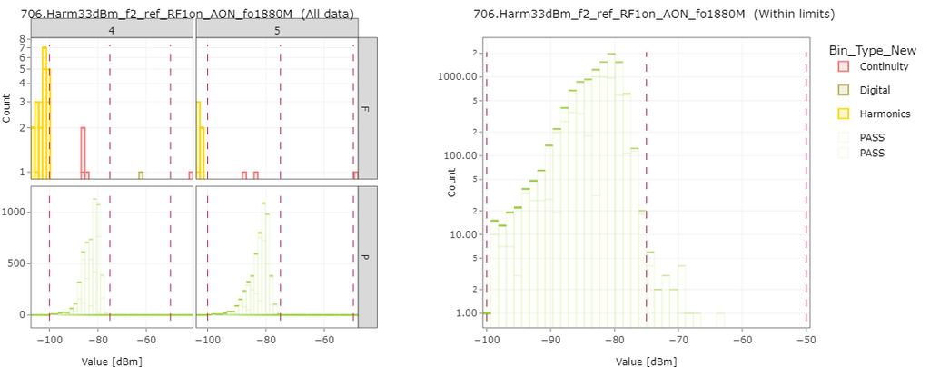

706_RangeP1_All data_LOT_1YUS77NT_WAFER_4_5_GROUP_Bin_Type_New_SPLIT_TRUE_PF_New_WAFER._FALSE_RangeP2_Within limits_706.png

706.Harm33dBm_f2_ref_RF1on_AON_fo1880M (No image available or redundant image)

### 105.Cont_A4_to_GND

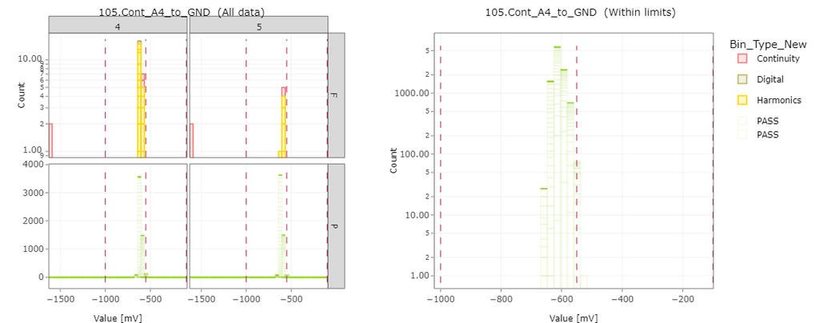

105_RangeP1_All data_LOT_1YUS77NT_WAFER_4_5_GROUP_Bin_Type_New_SPLIT_TRUE_PF_New_WAFER._FALSE_RangeP2_Within limits_105.png

105.Cont_A4_to_GND (No image available or redundant image)

### 102.Cont_A1_to_GND

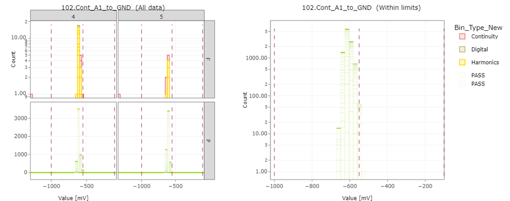

102_RangeP1_All data_LOT_1YUS77NT_WAFER_4_5_GROUP_Bin_Type_New_SPLIT_TRUE_PF_New_WAFER._FALSE_RangeP2_Within limits_102.png

102.Cont_A1_to_GND (No image available or redundant image)

### 107.Cont_B2_to_GND

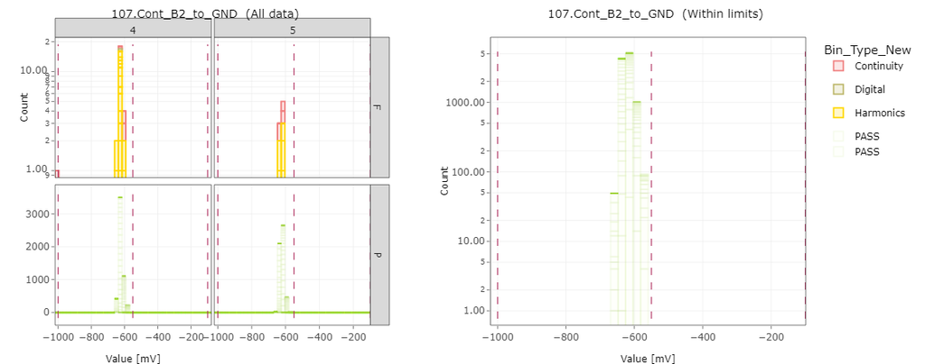

107_RangeP1_All data_LOT_1YUS77NT_WAFER_4_5_GROUP_Bin_Type_New_SPLIT_TRUE_PF_New_WAFER._FALSE_RangeP2_Within limits_107.png

107.Cont_B2_to_GND (No image available or redundant image)

### 300.Read_Manufacturer_ID

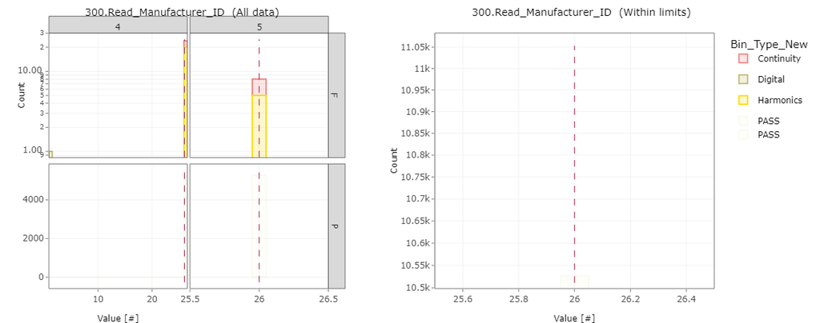

300_RangeP1_All data_LOT_1YUS77NT_WAFER_4_5_GROUP_Bin_Type_New_SPLIT_TRUE_PF_New_WAFER._FALSE_RangeP2_Within limits_300.png

300.Read_Manufacturer_ID (No image available or redundant image)

## Wafer-map

### 706.Harm33dBm_f2_ref_RF1on_AON_fo1880M

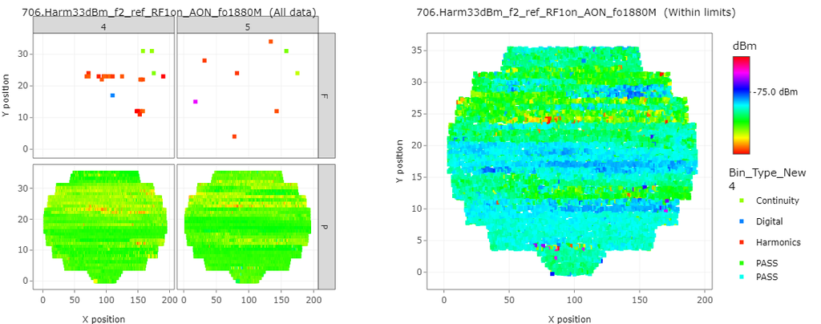

706_RangeP1_All data_LOT_1YUS77NT_WAFER_4_5_GROUP_Bin_Type_New_SPLIT_TRUE_PF_New_WAFER._FALSE_RangeP2_Within limits_706.png

706.Harm33dBm_f2_ref_RF1on_AON_fo1880M (No image available or redundant image)

### 105.Cont_A4_to_GND

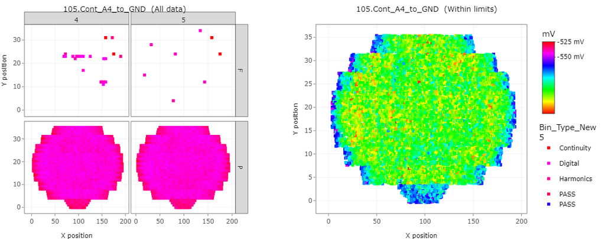

105_RangeP1_All data_LOT_1YUS77NT_WAFER_4_5_GROUP_Bin_Type_New_SPLIT_TRUE_PF_New_WAFER._FALSE_RangeP2_Within limits_105.png

105.Cont_A4_to_GND (No image available or redundant image)

### 102.Cont_A1_to_GND

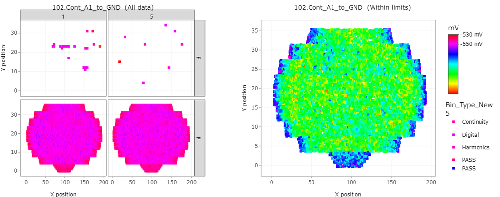

102_RangeP1_All data_LOT_1YUS77NT_WAFER_4_5_GROUP_Bin_Type_New_SPLIT_TRUE_PF_New_WAFER._FALSE_RangeP2_Within limits_102.png

102.Cont_A1_to_GND (No image available or redundant image)

### 107.Cont_B2_to_GND

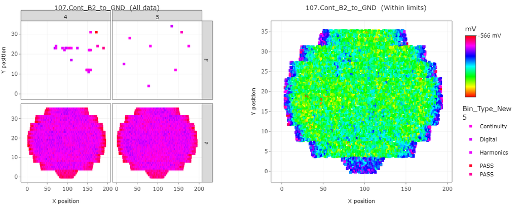

107_RangeP1_All data_LOT_1YUS77NT_WAFER_4_5_GROUP_Bin_Type_New_SPLIT_TRUE_PF_New_WAFER._FALSE_RangeP2_Within limits_107.png

107.Cont_B2_to_GND (No image available or redundant image)

### 300.Read_Manufacturer_ID

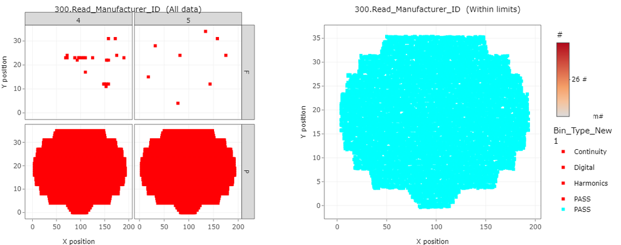

300_RangeP1_All data_LOT_1YUS77NT_WAFER_4_5_GROUP_Bin_Type_New_SPLIT_TRUE_PF_New_WAFER._FALSE_RangeP2_Within limits_300.png

300.Read_Manufacturer_ID (No image available or redundant image)

## Bin_Wafer-map

### 706.Harm33dBm_f2_ref_RF1on_AON_fo1880M

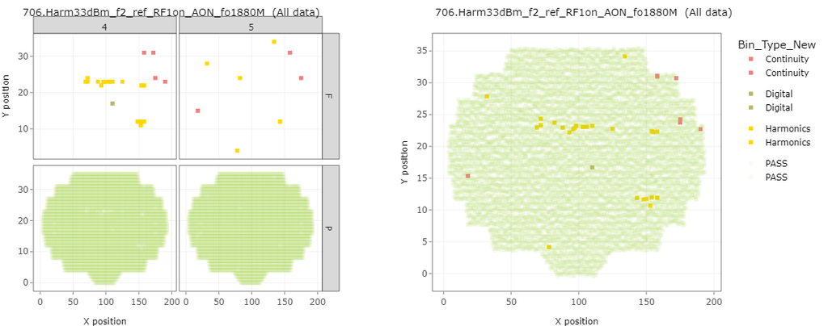

706_RangeP1_All data_LOT_1YUS77NT_WAFER_4_5_GROUP_Bin_Type_New_SPLIT_TRUE_PF_New_WAFER._FALSE_RangeP2_All data_706.png

706.Harm33dBm_f2_ref_RF1on_AON_fo1880M (No image available or redundant image)

105.Cont_A4_to_GND (No image available or redundant image)

102.Cont_A1_to_GND (No image available or redundant image)

107.Cont_B2_to_GND (No image available or redundant image)

300.Read_Manufacturer_ID (No image available or redundant image)

706.Harm33dBm_f2_ref_RF1on_AON_fo1880M (No image available or redundant image)

105.Cont_A4_to_GND (No image available or redundant image)

102.Cont_A1_to_GND (No image available or redundant image)

107.Cont_B2_to_GND (No image available or redundant image)

300.Read_Manufacturer_ID (No image available or redundant image)

## Scatter plot

### 706.Harm33dBm_f2_ref_RF1on_AON_fo1880M

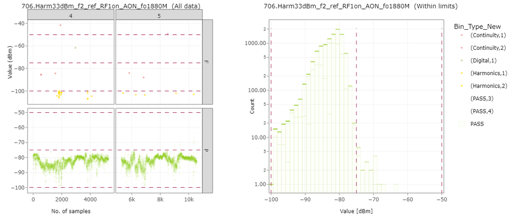

706_RangeP1_All data_LOT_1YUS77NT_WAFER_4_5_GROUP_Bin_Type_New_SPLIT_TRUE_PF_New_WAFER._FALSE_RangeP2_Within limits_706.png

706.Harm33dBm_f2_ref_RF1on_AON_fo1880M (No image available or redundant image)

### 105.Cont_A4_to_GND

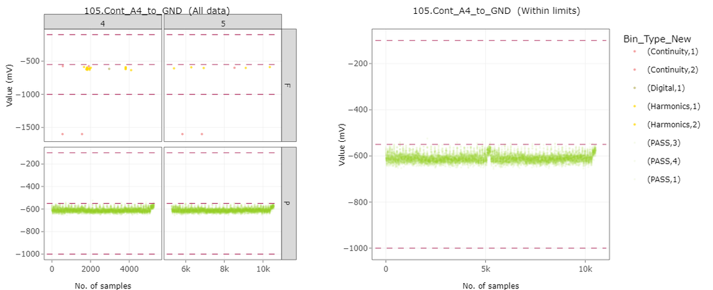

105_RangeP1_All data_LOT_1YUS77NT_WAFER_4_5_GROUP_Bin_Type_New_SPLIT_TRUE_PF_New_WAFER._FALSE_RangeP2_Within limits_105.png

105.Cont_A4_to_GND (No image available or redundant image)

### 102.Cont_A1_to_GND

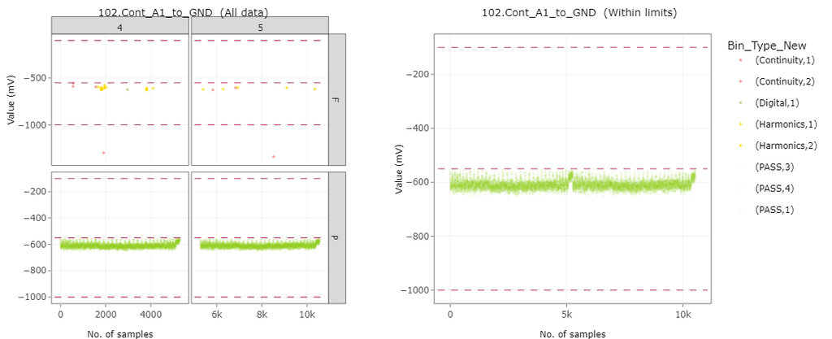

102_RangeP1_All data_LOT_1YUS77NT_WAFER_4_5_GROUP_Bin_Type_New_SPLIT_TRUE_PF_New_WAFER._FALSE_RangeP2_Within limits_102.png

102.Cont_A1_to_GND (No image available or redundant image)

### 107.Cont_B2_to_GND

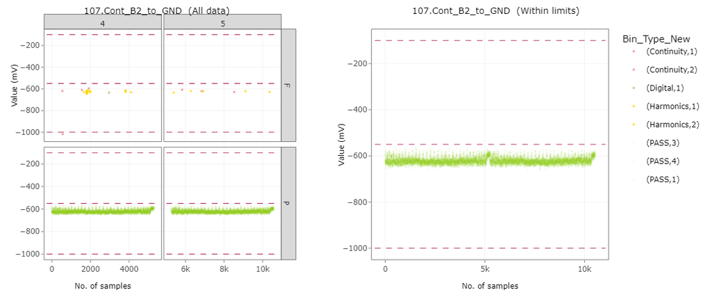

107_RangeP1_All data_LOT_1YUS77NT_WAFER_4_5_GROUP_Bin_Type_New_SPLIT_TRUE_PF_New_WAFER._FALSE_RangeP2_Within limits_107.png

107.Cont_B2_to_GND (No image available or redundant image)

### 300.Read_Manufacturer_ID

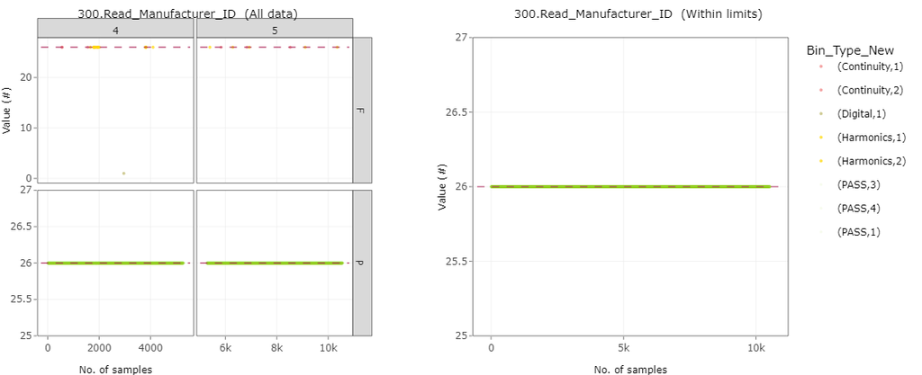

300_RangeP1_All data_LOT_1YUS77NT_WAFER_4_5_GROUP_Bin_Type_New_SPLIT_TRUE_PF_New_WAFER._FALSE_RangeP2_Within limits_300.png

300.Read_Manufacturer_ID (No image available or redundant image)

## Box plot

### 706.Harm33dBm_f2_ref_RF1on_AON_fo1880M

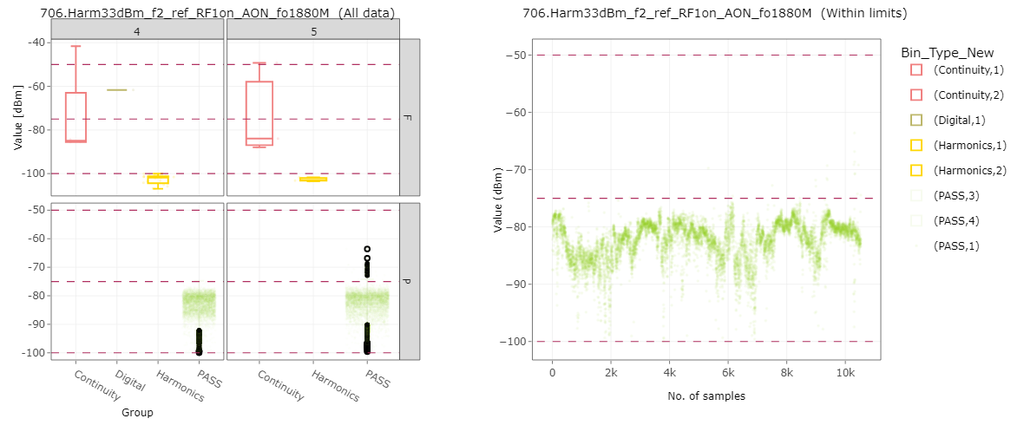

706_RangeP1_All data_LOT_1YUS77NT_WAFER_4_5_GROUP_Bin_Type_New_SPLIT_TRUE_PF_New_WAFER._FALSE_RangeP2_Within limits_706.png

706.Harm33dBm_f2_ref_RF1on_AON_fo1880M (No image available or redundant image)

### 105.Cont_A4_to_GND

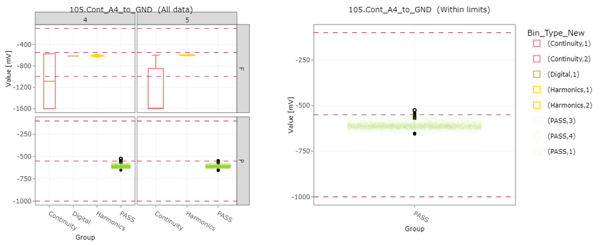

105_RangeP1_All data_LOT_1YUS77NT_WAFER_4_5_GROUP_Bin_Type_New_SPLIT_TRUE_PF_New_WAFER._FALSE_RangeP2_Within limits_105.png

105.Cont_A4_to_GND (No image available or redundant image)

### 102.Cont_A1_to_GND

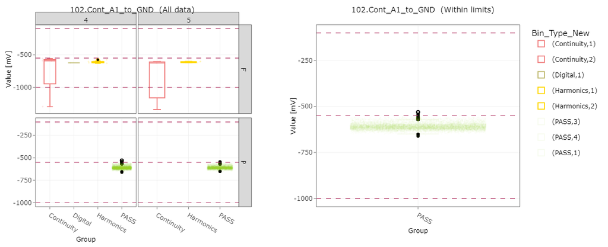

102_RangeP1_All data_LOT_1YUS77NT_WAFER_4_5_GROUP_Bin_Type_New_SPLIT_TRUE_PF_New_WAFER._FALSE_RangeP2_Within limits_102.png

102.Cont_A1_to_GND (No image available or redundant image)

### 107.Cont_B2_to_GND

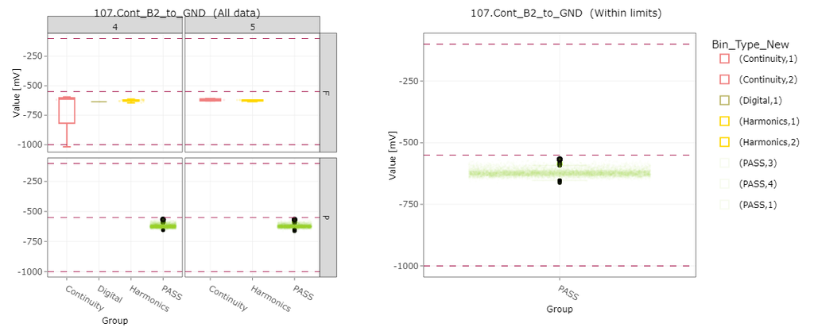

107_RangeP1_All data_LOT_1YUS77NT_WAFER_4_5_GROUP_Bin_Type_New_SPLIT_TRUE_PF_New_WAFER._FALSE_RangeP2_Within limits_107.png

107.Cont_B2_to_GND (No image available or redundant image)